# Schmidt_Emily_TP2

Emily Schmidt

2024-01-06

# 1 Exercise 4

Dataset global_economy contains the annual Exports from many countries. Select one country to analyse.

```
## # A tsibble: 10 x 9 [1Y]
## # Key:       Country [1]
##    Country     Code   Year         GDP Growth   CPI Imports Exports Population
##    <fct>       <fct> <dbl>       <dbl>  <dbl> <dbl>   <dbl>   <dbl>      <dbl>
##  1 Afghanistan AFG    1960  537777811.     NA    NA    7.02    4.13    8996351
##  2 Afghanistan AFG    1961  548888896.     NA    NA    8.10    4.45    9166764
##  3 Afghanistan AFG    1962  546666678.     NA    NA    9.35    4.88    9345868
##  4 Afghanistan AFG    1963  751111191.     NA    NA   16.9     9.17    9533954
##  5 Afghanistan AFG    1964  800000044.     NA    NA   18.1     8.89    9731361
##  6 Afghanistan AFG    1965 1006666638.     NA    NA   21.4    11.3     9938414
##  7 Afghanistan AFG    1966 1399999967.     NA    NA   18.6     8.57   10152331
##  8 Afghanistan AFG    1967 1673333418.     NA    NA   14.2     6.77   10372630
##  9 Afghanistan AFG    1968 1373333367.     NA    NA   15.2     8.90   10604346
## 10 Afghanistan AFG    1969 1408888922.     NA    NA   15.0    10.1    10854428
```

[output not shown]

[output cut: 65 more lines]

[output not shown]

```
## [1] 15150     9
```

```
## # A tsibble: 15,150 x 9 [1Y]
## # Key:       Country [263]
##    Country     Code   Year         GDP Growth   CPI Imports Exports Population
##    <fct>       <fct> <dbl>       <dbl>  <dbl> <dbl>   <dbl>   <dbl>      <dbl>
##  1 Afghanistan AFG    1960  537777811.     NA    NA    7.02    4.13    8996351
##  2 Afghanistan AFG    1961  548888896.     NA    NA    8.10    4.45    9166764
##  3 Afghanistan AFG    1962  546666678.     NA    NA    9.35    4.88    9345868
##  4 Afghanistan AFG    1963  751111191.     NA    NA   16.9     9.17    9533954
##  5 Afghanistan AFG    1964  800000044.     NA    NA   18.1     8.89    9731361
##  6 Afghanistan AFG    1965 1006666638.     NA    NA   21.4    11.3     9938414
##  7 Afghanistan AFG    1966 1399999967.     NA    NA   18.6     8.57   10152331
##  8 Afghanistan AFG    1967 1673333418.     NA    NA   14.2     6.77   10372630
##  9 Afghanistan AFG    1968 1373333367.     NA    NA   15.2     8.90   10604346
## 10 Afghanistan AFG    1969 1408888922.     NA    NA   15.0    10.1    10854428
## # ℹ 15,140 more rows
```

## 1.1 Question 1

Plot the Exports series for selected country and discuss the main features of the data.

```
## [1] 1
```

```
## # A tibble: 58 × 2
##    Country Exports
##    <fct>     <dbl>
##  1 Italy      12.5
##  2 Italy      12.8
##  3 Italy      12.7
##  4 Italy      12.2
##  5 Italy      12.8
##  6 Italy      14.3
##  7 Italy      14.7
##  8 Italy      14.5
##  9 Italy      15.2
## 10 Italy      15.8
## # ℹ 48 more rows
```

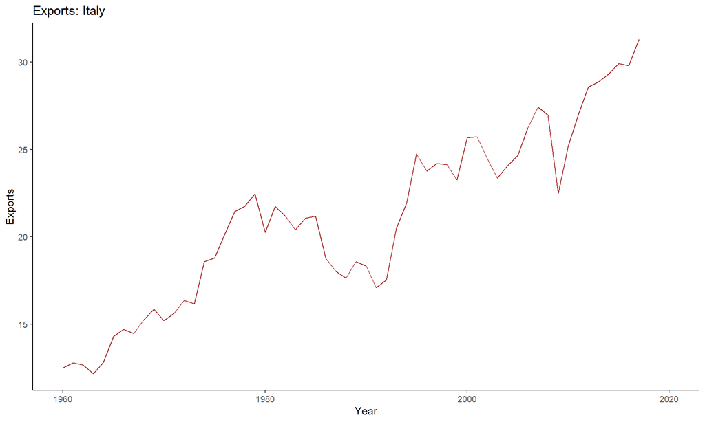

The Italian exports data is interesting from a historical context. Overall, there is an increasing trend over a 58 year time span starting in 1960. About two decades later, there was an economic recession that severely impacted this specific industry. This decline occurred for about 10 years until the early 1990s. Then, the devaluation of the lira sparked an increase in moving goods because it made Italian exports more competitive in foreign markets. Although there does not seem to be seasonality, the increasing trend repetitively falls and rises for several years until the recession in 2008. This caused trouble in the Italian exports because the demand for certain products that they were leading manufacturers in significantly decreased. After this period of turmoil, they managed to get their export trend moving in a positive direction.

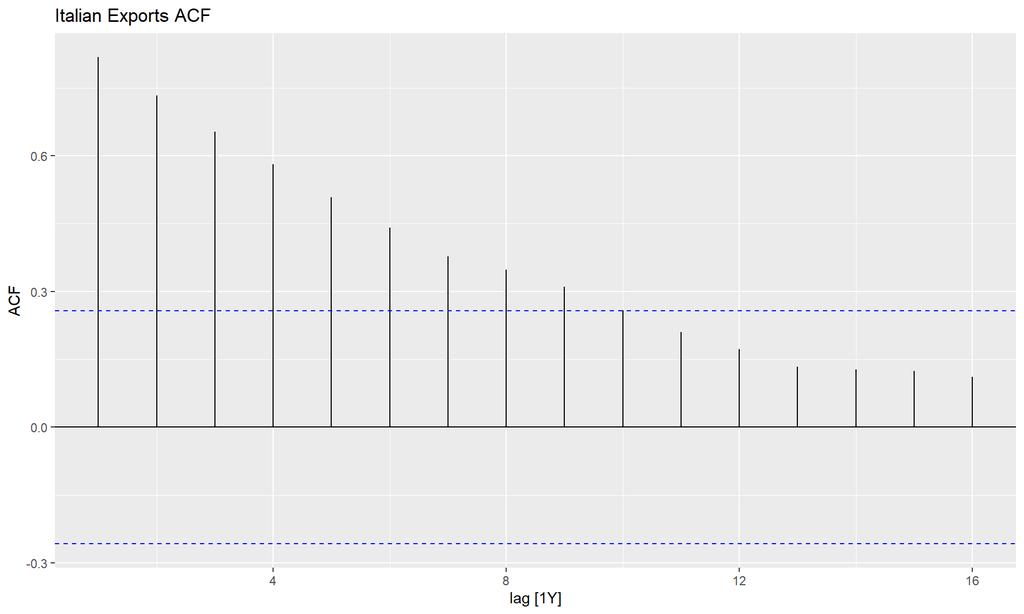

If seasonality were present, there would be larger seasonal lags at specific frequencies appearing multiple times. Unfortunately, these types of patterns do not appear. As stated earlier, an overall positive trend for the Italian exports is seen, and the correlogram shows what will happen x lags after the nearest observation in time. The smaller lags are quite larger as the lags continue in time. This means that ‘the ACF trended time series tend to have positive values that slowly decrease as the lags increase.’ Additionally, when one or more spikes are outside of the dashed lines, it means that the series is most likely not white noise.

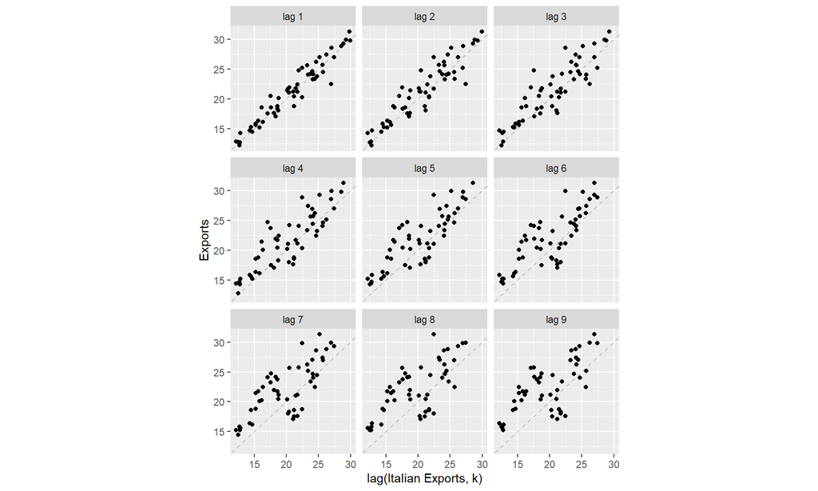

As the lags increase, the relationship between annual Italian exports become weaker. This is seen as the data points are not aligning with the dotted line because the data continues to disperse.

## 1.2 Question 2

Use one of the viewed methods (simple exponential smoothing, Holt, Holt-Winter) which is appropriated to your series. Justify your choice. Comment on your model’s parameter(s). How well does your model fit the data?

### 1.2.1 SES (naïve)

*Method*: No trend, no seasonality

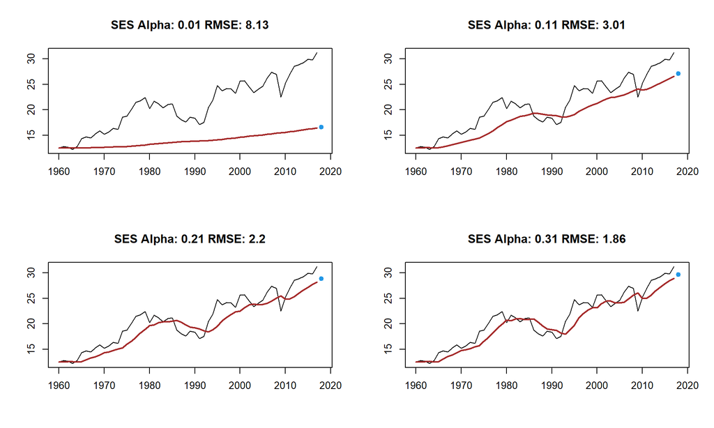

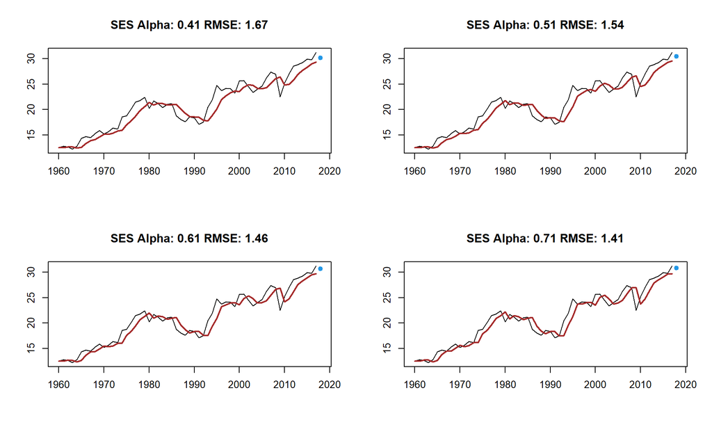

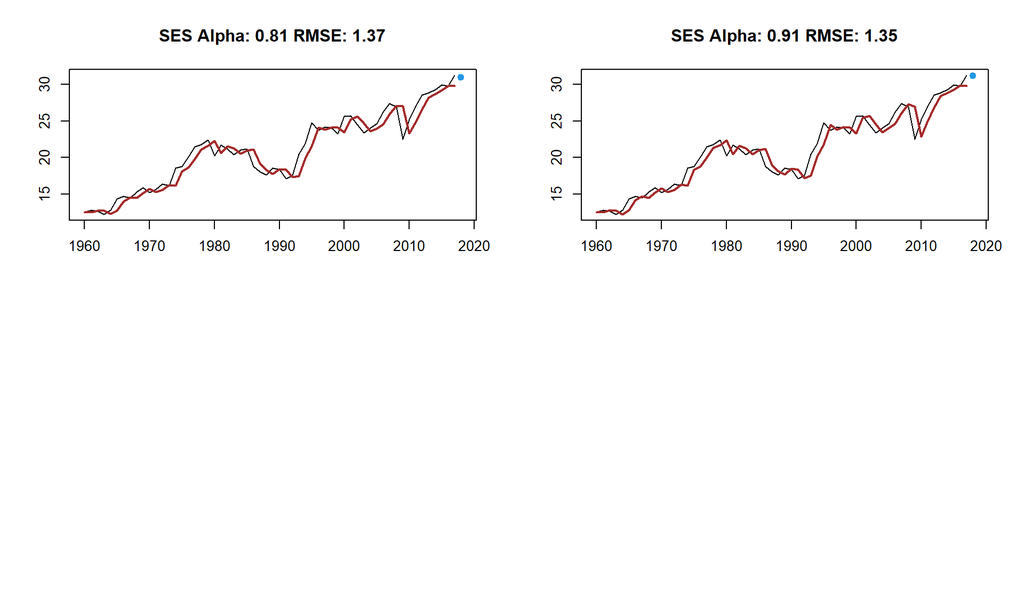

```
## ETS(A,N,N)
##
## Call:
##  ets(y = Italy_exports_ts, model = "ANN", damped = FALSE)
##
##   Smoothing parameters:
##     alpha = 0.9999
##
##   Initial states:
##     l = 12.4972
##
##   sigma:  1.3587
##
##      AIC     AICc      BIC
## 275.0274 275.4719 281.2087
##
## Training set error measures:
##                     ME     RMSE     MAE      MPE     MAPE      MASE
## Training set 0.3241565 1.335065 1.00209 1.388913 4.752898 0.9827774
##                      ACF1
## Training set -0.007011304
```

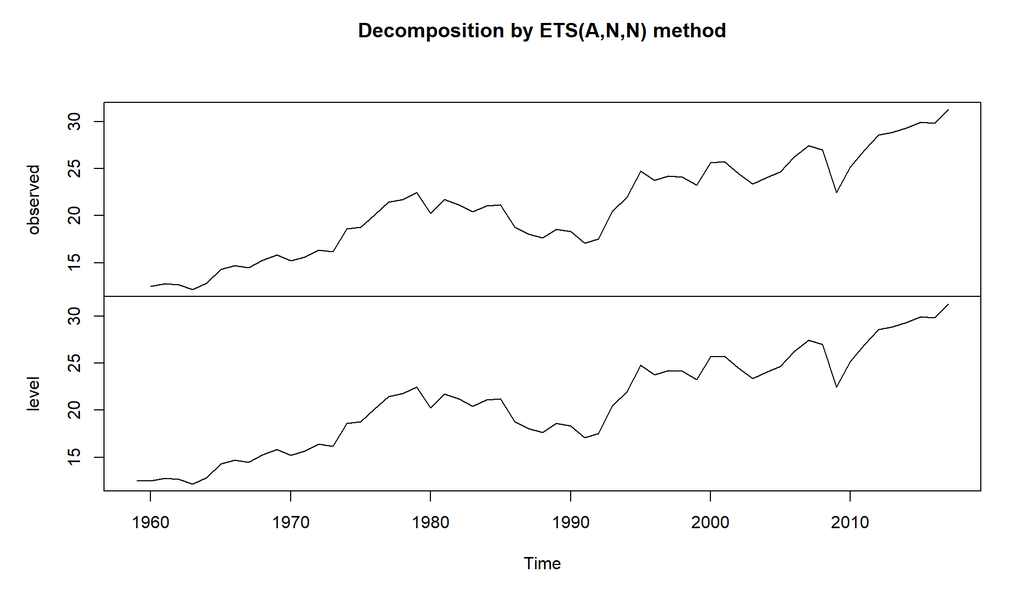

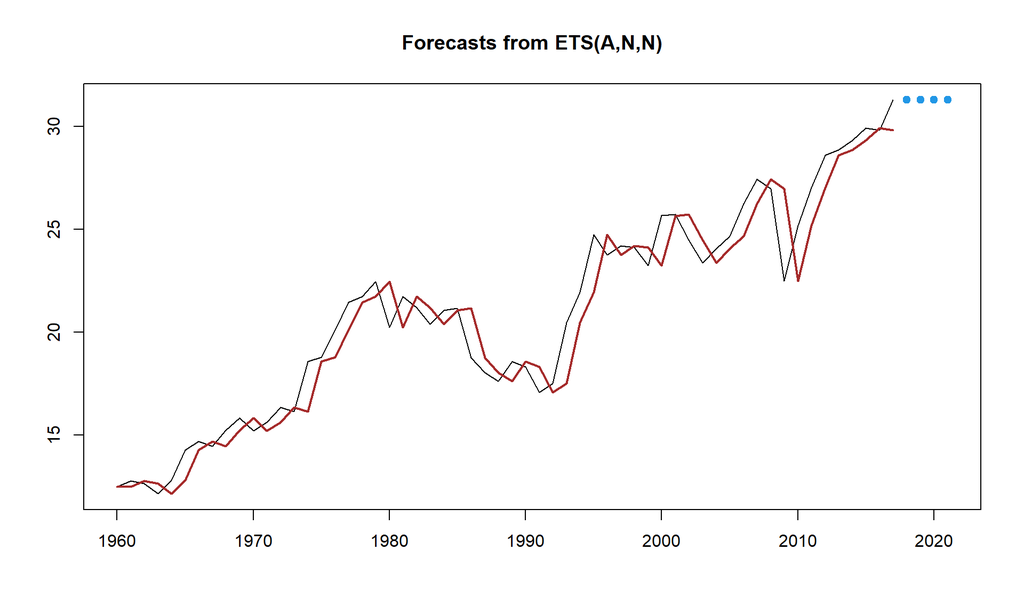

The best $\alpha$ is 0.91 because the RMSE is the lowest at 1.35. The SES method forecasts that all points within the time series are equally weighted to the last observed value. Since this is not optimal, typically one would seek to put larger weights on most recent observations and less to those father away. As the $\alpha$ value increases, the model will put more weight to the most recent observations.

- Forecast equation: $\hat{y}_{t+h|t} = l_t$
- Level equation: $l_t = {\alpha}{y_t} + (1 - \alpha)l_{t-1}$

### 1.2.2 Holt’s Linear Trend Method

*Method*: Trend, no seasonality

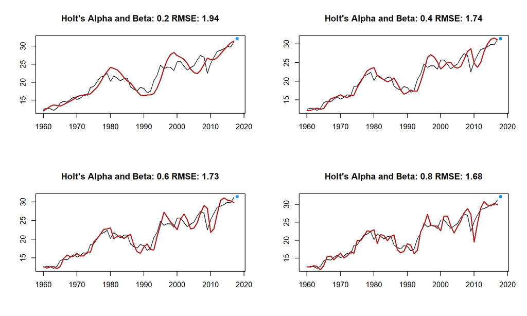

### 1.2.3 Holt’s Linear Trend Method (Additional Details)

*Method*: Trend, no seasonality

```
## ETS(A,A,N)
##
## Call:
##  ets(y = Italy_exports_ts, model = "AAN", damped = FALSE)
##
##   Smoothing parameters:
##     alpha = 0.9485
##     beta  = 1e-04
##
##   Initial states:
##     l = 12.1977
##     b = 0.3364
##
##   sigma:  1.3424
##
##      AIC     AICc      BIC
## 275.5212 276.6751 285.8235
##
## Training set error measures:
##                        ME     RMSE       MAE       MPE     MAPE      MASE
## Training set -0.008409678 1.295316 0.9337333 -0.290676 4.469843 0.9157377
##                    ACF1
## Training set 0.03752767
```

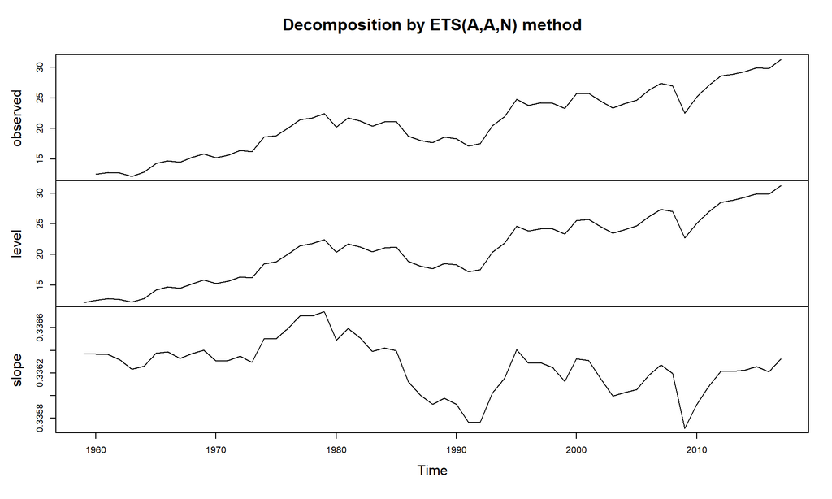

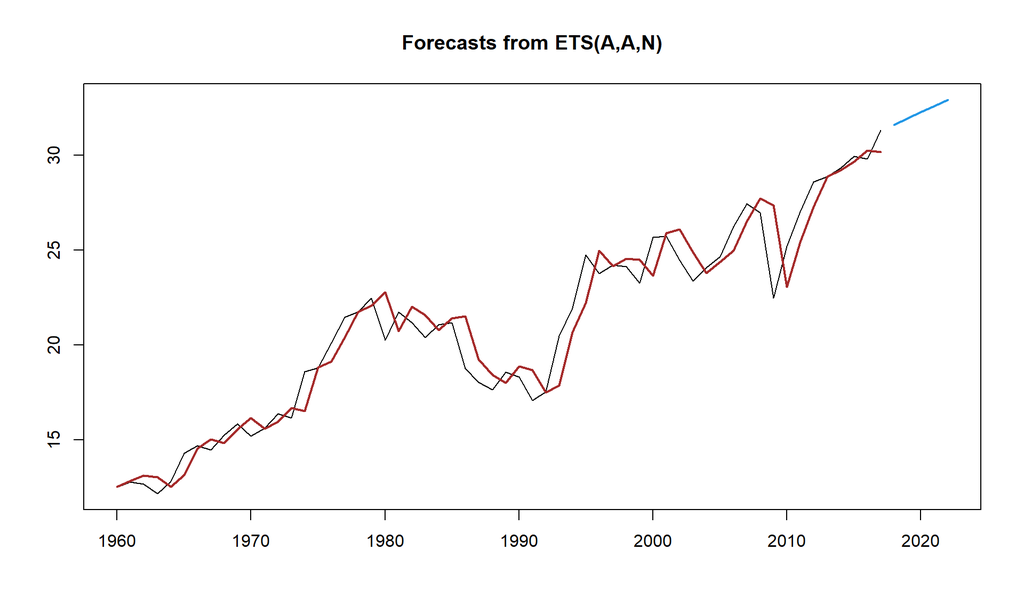

### 1.2.4 Holt’s Linear Trend Method (Damped)

*Method*: Trend, no seasonality

```
## ETS(A,Ad,N)
##
## Call:
##  ets(y = Italy_exports_ts, model = "AAN", damped = TRUE)
##
##   Smoothing parameters:
##     alpha = 0.9999
##     beta  = 1e-04
##     phi   = 0.9796
##
##   Initial states:
##     l = 11.3768
##     b = 0.4656
##
##   sigma:  1.3645
##
##      AIC     AICc      BIC
## 278.3321 279.9792 290.6948
##
## Training set error measures:
##                     ME     RMSE       MAE        MPE     MAPE      MASE
## Training set 0.0743749 1.304402 0.9661937 0.06856984 4.637248 0.9475726
##                      ACF1
## Training set -0.001637108
```

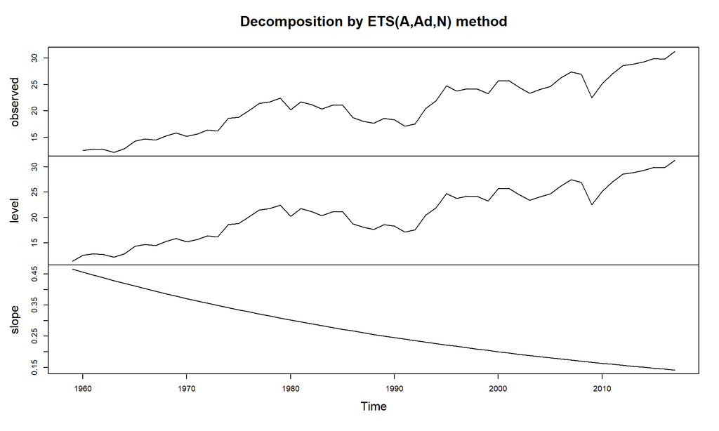

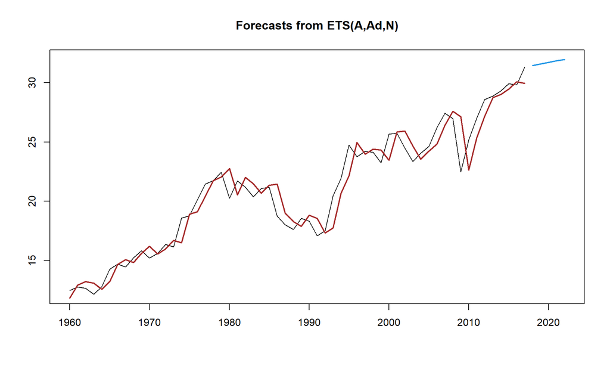

In Holt’s model, this allows the SES to be extended to include the trend within the forecast data. In practice, this means that the forecast function is not considered flat but is trending. According to the book, ’the *h*-step-ahead forecast is equal to the last estimated level plus *h* times the last estimated trend value. Hence the forecasts are a linear function of *h*. In addition to the SES equations, Holt’s linear method introduces $\beta$, the slope.

Additionally, the damped trend method was used in Holt’s model. Realistically, a constant positive or negative trend continuing indefinitely into the future is most likely not going to occur. Therefore, damping a trend means that it is flatten into the years to come.

### 1.2.5 Holt-Winter Method

*Method*: Trend, Seasonality  
Since there have been multiple models showing that seasonality within the trended data does not exist, this method will not be ran in *R* since it uses an additional smoothing equation to account for frequency of that constant variation in seasons.

Overall, the **Holt Undamped** model seems to be the most appropriate. The SES would not be considered as the method does not take into account a trend. Therefore, the graph shows a constant flat line for the for the next four observations which is not realistic when discussing Italian exports. The optimal RMSE was 1.34 with a smoothing parameter ($\alpha$) at 0.9999. The Hot-Winter model is immediately ruled out since the correlogram shows no pattern of seasonality. The best method is Holt’s due to the nature of the trending data. The next question to raise though is if the model should be dampened. According to the RMSEs (best fit) of the two models, the undamped methods seems to be slightly better with a RMSE of 1.295 compared to 1.304. But, as the book mentioned, the damped methods have been proven to be exceedingly successful. This decision is a toss up due to the closeness of the RMSEs and the measure of dampness. Therefore, the recommended model would be **Holt Undamped**. To ensure that this is the right model though, discussing with an expert is crucial. For this method, there are three parameters to take into consideration.

## 1.3 Question 3

Run model with different values of the parameter(s). Plot it against parameter(s) values. How each parameter does impact the forecast?

```
## ETS(A,A,N)
##
## Call:
##  ets(y = Italy_exports_ts, model = "AAN", damped = FALSE, alpha = 0.9,
##
##  Call:
##      beta = 0.8)
##
##   Smoothing parameters:
##     alpha = 0.9
##     beta  = 0.8
##
##   Initial states:
##     l = 12.3673
##     b = 0.1859
##
##   sigma:  1.7321
##
##      AIC     AICc      BIC
## 301.0838 301.5282 307.2651
##
## Training set error measures:
##                      ME     RMSE      MAE        MPE     MAPE    MASE      ACF1
## Training set 0.02079039 1.671304 1.224653 0.05957714 5.883705 1.20105 -0.227401
```

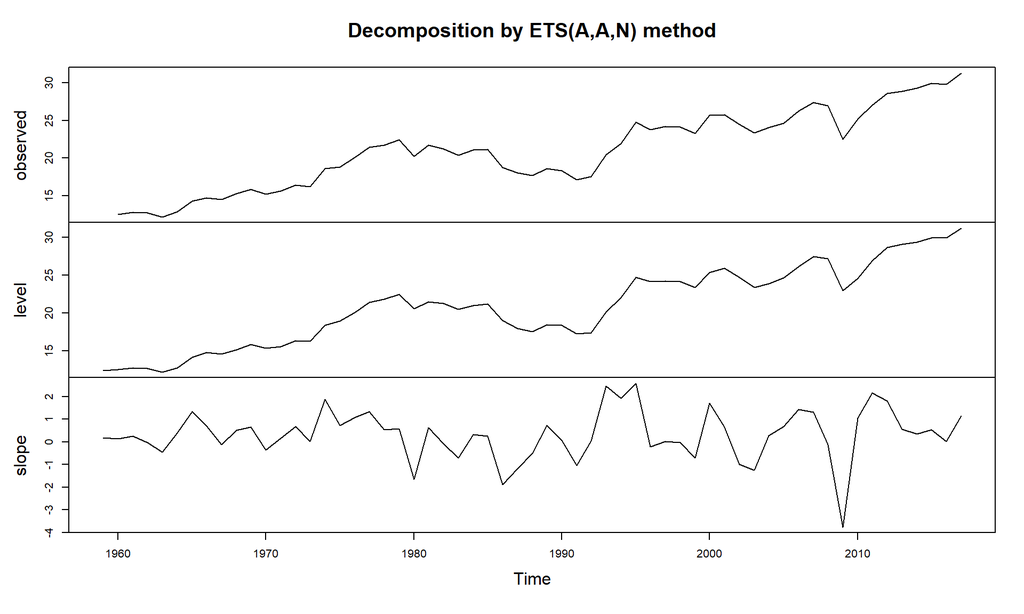

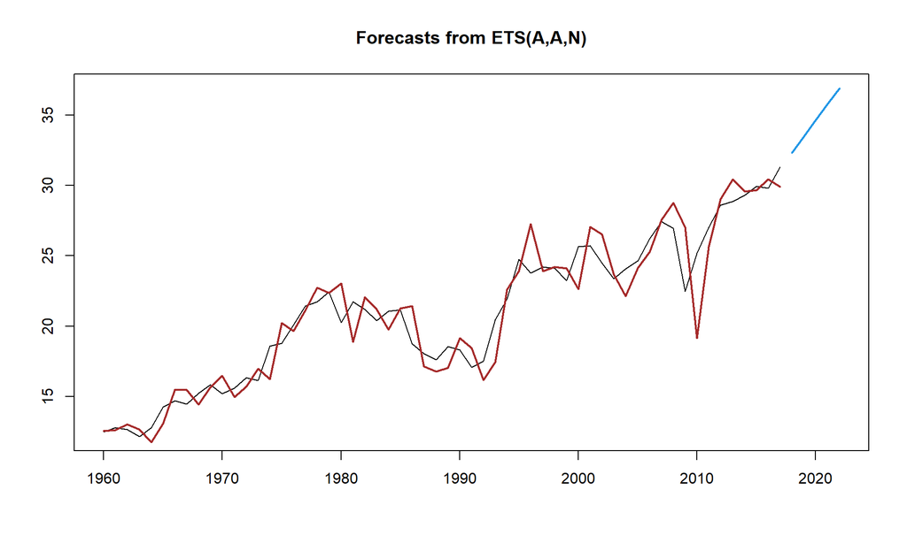

This table represents the different values for each of the models parameters:

```
##   Alpha  Beta     RMSE
## 1   0.2 0.001 1.739570
## 2   0.5 0.001 1.420927
## 3   0.8 0.001 1.312309
## 4   0.9 0.100 1.355105
## 5   0.9 0.500 1.529634
## 6   0.9 0.800 1.671304
```

Comments:

1. Very smooth trending line
2. Smoother trend, follows the original data more closely
3. Rigid trend line
4. Looks like the forecasting line has just been shifted to the right
5. The amplitude of the peaks and dips have elongated
6. The amplitudes have elongated even more than beta is 0.5

The $\alpha$ smoothing parameter impacts the smoothness of the level because it is the weight at which rates are controlled. On the other hand, $\beta$ represents the slope and how it impacts this smoothing parameter.

## 1.4 Question 4

Provide forecast for 5 steps ahead. Does your prediction look good? Please, explain.

```
##
## Forecast method: Holt's method
##
## Model Information:
## Holt's method
##
## Call:
##  holt(y = Italy_exports_ts, h = 5, initial = "optimal")
##
##   Smoothing parameters:
##     alpha = 0.9485
##     beta  = 1e-04
##
##   Initial states:
##     l = 12.1963
##     b = 0.3366
##
##   sigma:  1.3424
##
##      AIC     AICc      BIC
## 275.5212 276.6751 285.8235
##
## Error measures:
##                        ME     RMSE       MAE        MPE     MAPE     MASE
## Training set -0.008657762 1.295316 0.9336816 -0.2918513 4.469588 0.915687
##                   ACF1
## Training set 0.0375028
##
## Forecasts:
##      Point Forecast    Lo 80    Hi 80    Lo 95    Hi 95
## 2018       31.57466 29.85426 33.29506 28.94354 34.20578
## 2019       31.91124 29.53991 34.28258 28.28460 35.53789
## 2020       32.24783 29.36907 35.12658 27.84515 36.65050
## 2021       32.58441 29.27506 35.89376 27.52319 37.64563
## 2022       32.92099 29.23088 36.61111 27.27745 38.56454
```

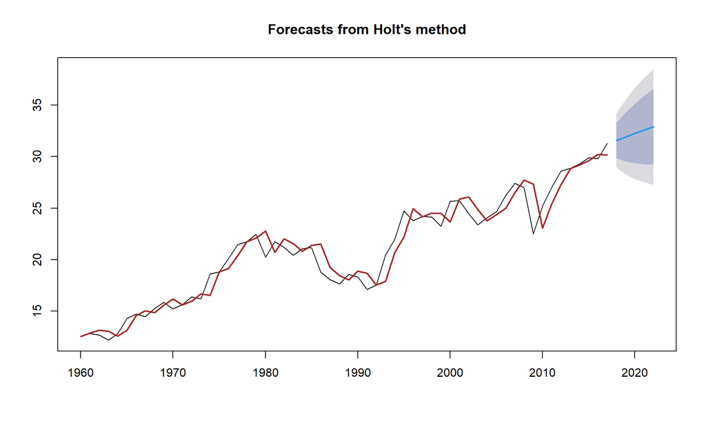

Through Holt’s undamped model, the next five (5) years are forecasted. From the original times series, the next observations seem to align pretty well with how the model generates those predictions. In addition, the light blue line that represents those five years which fall within the prediction intervals. This means that those observations fall within the range of the likely values for future data points.

## 1.5 Optional Question

Repeat your analysis for another country applying different method.

```
## [1] 27
```

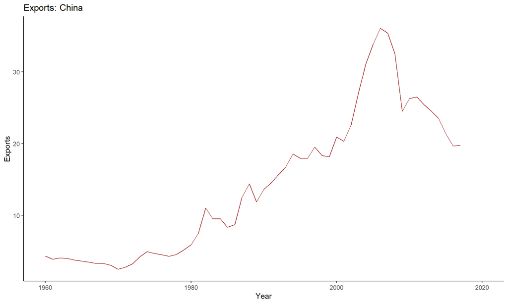

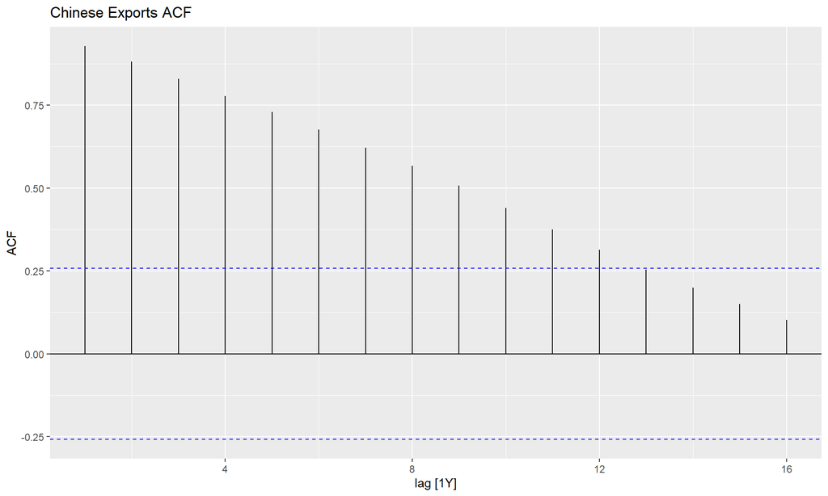

```
## ETS(A,Ad,N)
##
## Call:
##  ets(y = China_exports_ts, model = "AAN", damped = TRUE)
##
##   Smoothing parameters:
##     alpha = 0.9999
##     beta  = 0.2486
##     phi   = 0.8
##
##   Initial states:
##     l = 3.9664
##     b = -0.1171
##
##   sigma:  1.9315
##
##      AIC     AICc      BIC
## 318.6424 320.2894 331.0050
##
## Training set error measures:
##                     ME     RMSE      MAE      MPE     MAPE      MASE      ACF1
## Training set 0.1216489 1.846417 1.243463 1.175033 9.568246 0.9696529 0.1069137
```

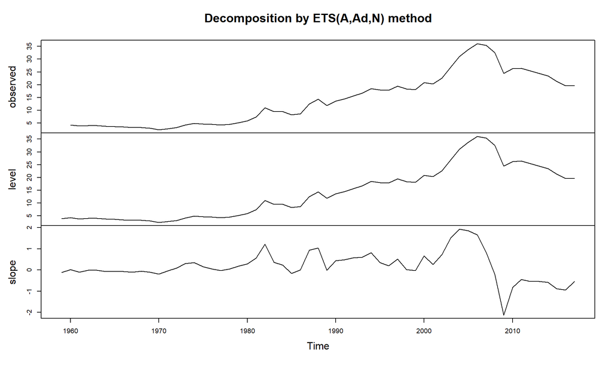

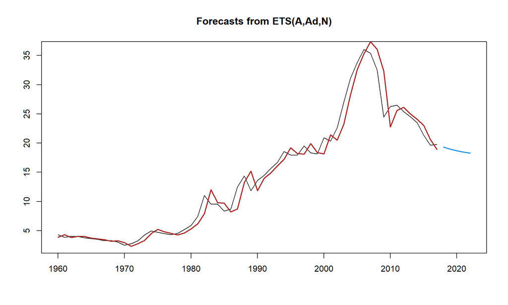

```
## ETS(A,A,N)
##
## Call:
##  ets(y = China_exports_ts, model = "AAN", damped = FALSE)
##
##   Smoothing parameters:
##     alpha = 0.9999
##     beta  = 0.0992
##
##   Initial states:
##     l = 4.0399
##     b = 0.1
##
##   sigma:  1.9758
##
##      AIC     AICc      BIC
## 320.3530 321.5069 330.6552
##
## Training set error measures:
##                       ME     RMSE      MAE        MPE     MAPE      MASE
## Training set -0.08543025 1.906436 1.247959 -0.1688151 9.566581 0.9731588
##                   ACF1
## Training set 0.2323057
```

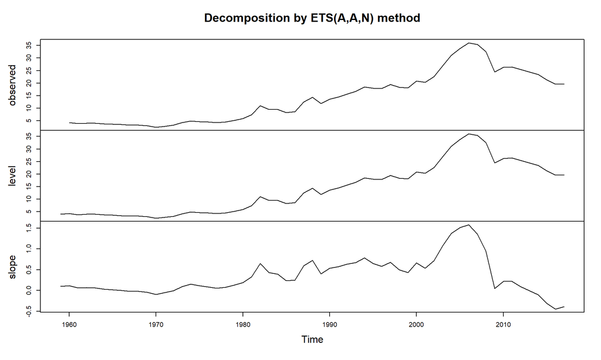

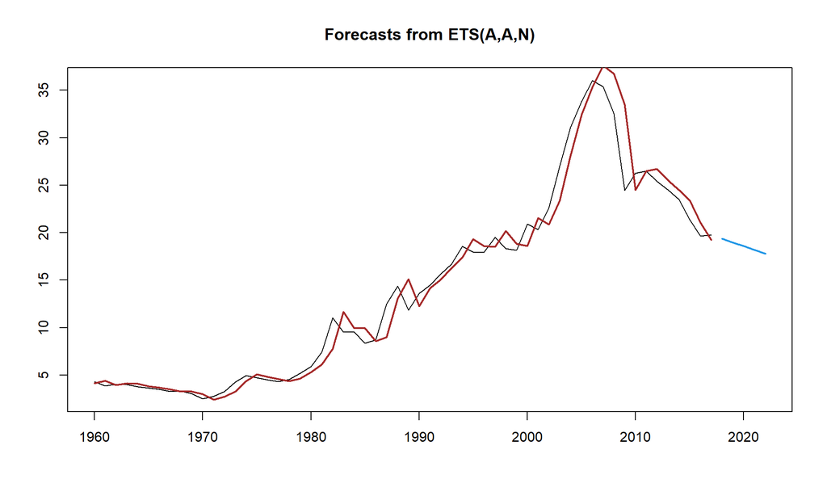

Since China is the largest exporter in the world, it made sense to look at their data to see if it differed from how Italy exports. The country’s export trend is relatively positive, and there appears to be no sign of seasonality according to the ACF chart. From the early 2000s, there was a steep incline of exports and this was due to factors such as China joining the World Trade Organization, expansion of manufacturing sector, and trade surplus among a few. Just as exports fell in Italy in around 2008, the same thing happened to China. Unfortunately, they did not recover as quickly since their trend seems to be declining now which could be due to other economic factors. Since a trend is present, Holt’s model would be the best. The difference for China though is that the better model is one with the damped effect of 80% as the RMSE is 1.85 compared to 1.91 with undamped.